# Dec. 1 Committee Meeting

Molly Wilson

12/1/2017

# 1 Meeting objectives

- Go through where I’m at in terms of chapters: progress and planning
  - Perspective paper on behavioral effects of human activities
  - Fieldwork investigating variations in Scarid grazing across systems with different levels of human impact
  - Linking behavior to potential ecological effects - likely through herbivory model
  - Additional chapter: social-ecological impacts of parrotfish fishing ban in DR?
- Where I need to get myself in terms of oral exams
- Scheduling next meetings, sign Annual Review form

# 2 Scarid grazing data + analysis

## 2.1 Intro to the data

**Hypothesis**: herbivorous fish (scarids) have reduced grazing impact in low herbivore biomass (high herb. fishing) systems

- scarids feeding rates increase with scarid biomass
- foray size (bites/foray) and duration increase with scarid biomass
- 795 follows (2-min)
- 13 sites across 3 islands (Antigua, Barbuda, Bonaire)
- 2 focal species in Bonaire (Scarus vetula, Sparisoma viride - dominant grazers), but added Sparisoma aurofrenatum in Antigua & Barbuda because of low densities of viride and vetula in some sites
- Possibility to integrate fish follow data from FL Keys and St. Croix (Burkepile), and Belize and Bahamas (Mumby)

Site-level predictor variables:

- fish community data: scarid biomass, scarid density, carnivore biomass
- benthic community data: percent coral cover, percent turf algal cover, percent macroalgal cover, turf canopy height, macroalgal canopy height
- rugosity

Indv. fish-level predictor variables:

- species
- phase
- length

Indv. fish-level response variables:

- fraction of time spent grazing (**g.frac**)
- bite rate while grazing (bites/sec) (**BR**)
- feeding rate (overall bite rate, bites/hr) (**FR**)
- total daily bites (**TDB**)
- foray size (bites per foray) (**for.bites**)
- foray duration (seconds) (**for.dur**)

Not done with analyses, but will introduce you to where I’m at….

## 2.2 Exploring predictors of grazing behavior

### 2.2.1 Grazing as a function of scarid biomass

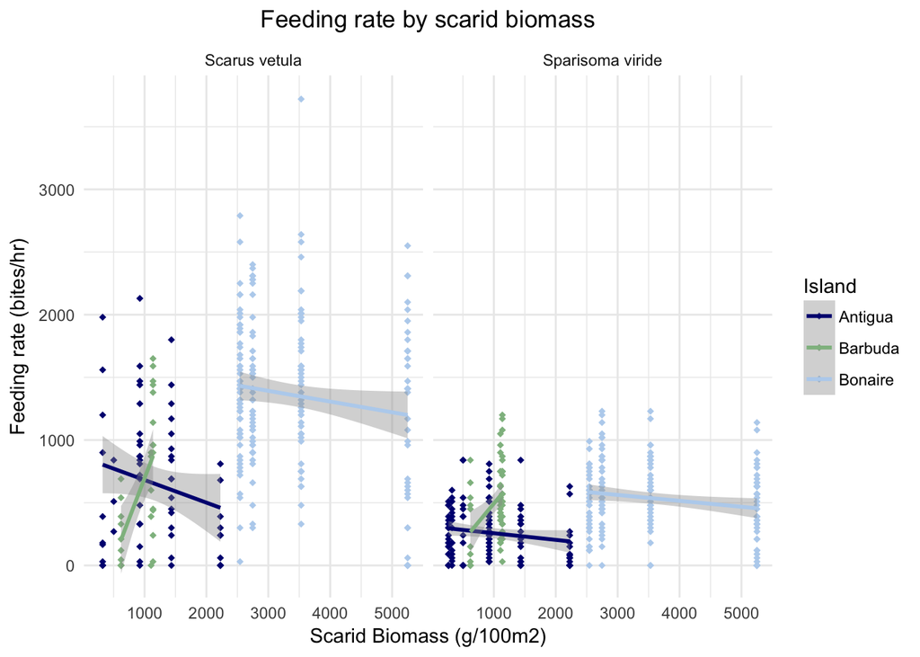

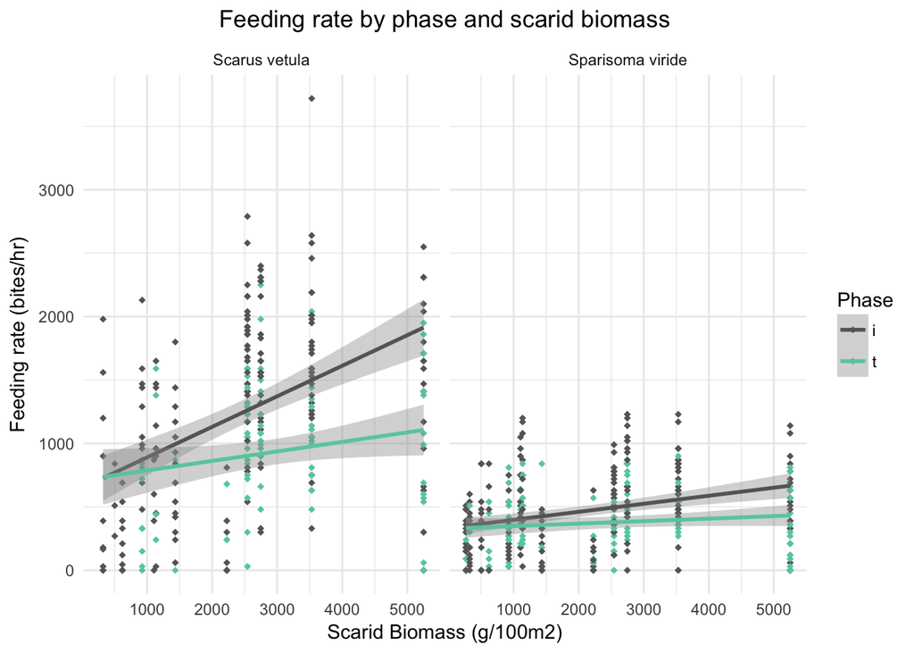

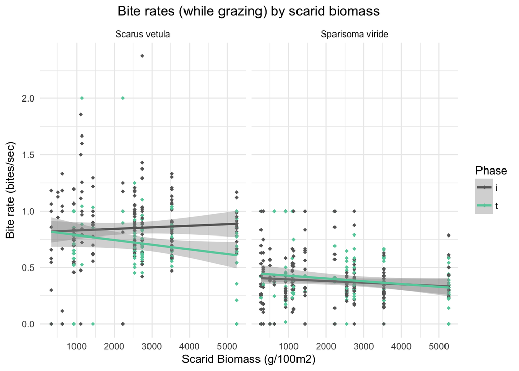

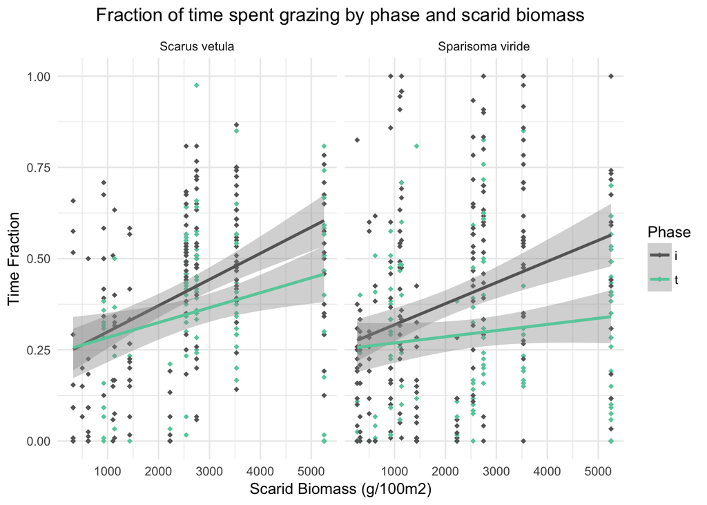

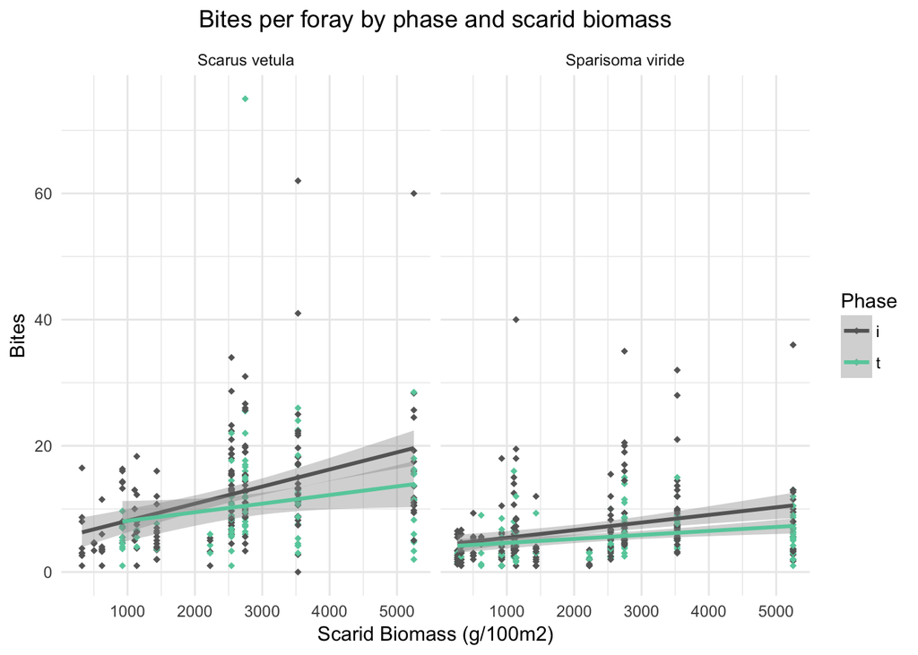

### 2.2.2 Grazing PCAs

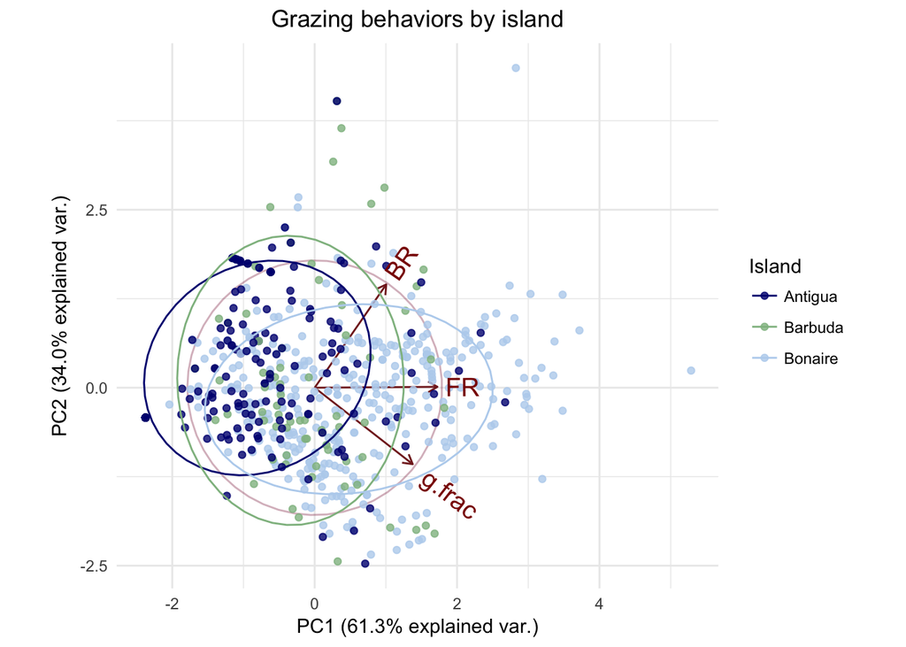

### 2.2.3 Grazing as a function of fish length

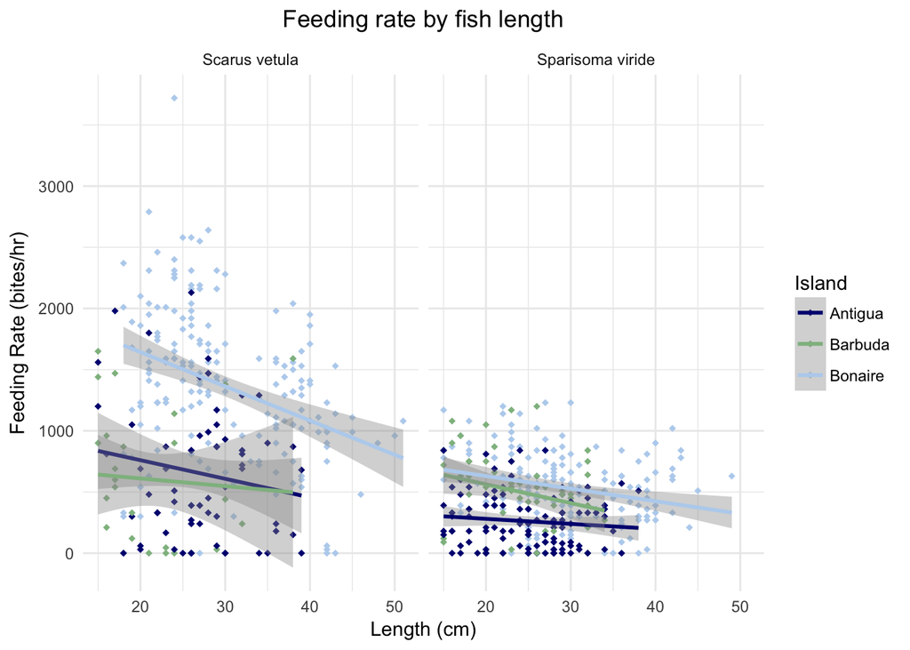

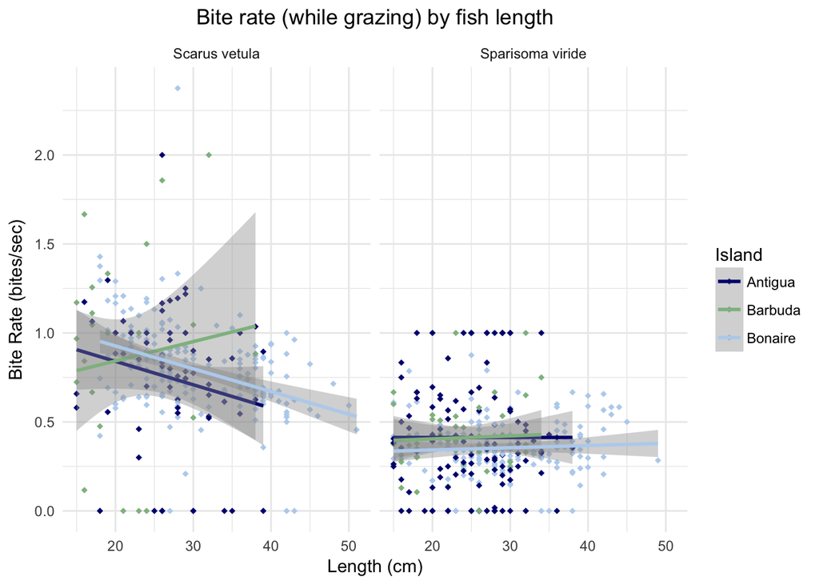

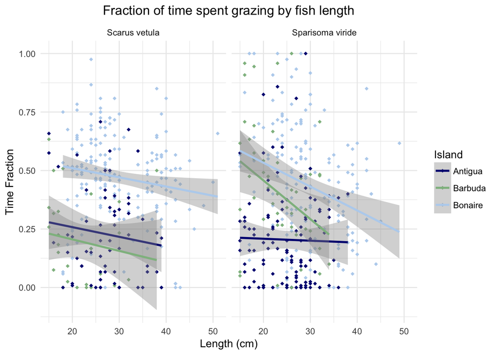

## 2.3 Correlations among predictor variables

Strong correlations between scarid biomass and both carnivore biomass and coral cover. I can address benthic corelations via PCA but don’t really want to pool the fish predictors I’m interested in?

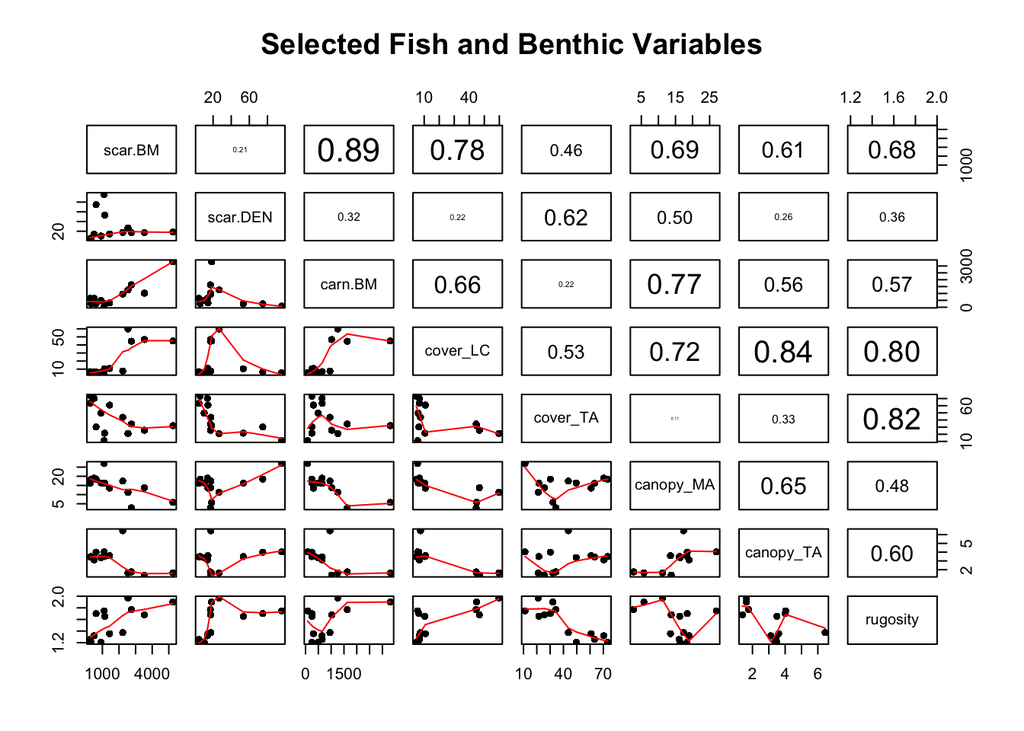

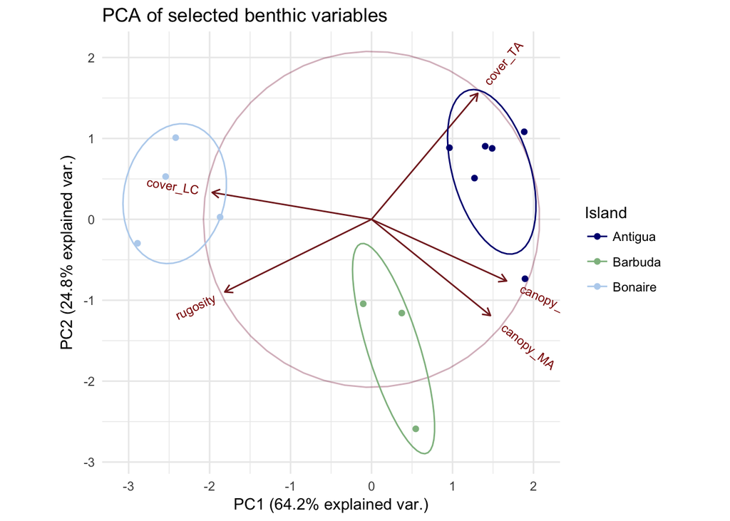

## 2.4 Mixed effect models

Investigating drivers of grazing behavior

### 2.4.1 Feeding rates

```r
vetvir <- data %>% filter(Species.Code!="rbp")
lme_FR <- lme(FR~Phase+Length.cm+Species*scar.BM+scar.DEN+carn.BM+PC1+PC2,data=vetvir,random=~1|Island, na.action = na.omit)
summary(lme_FR)
```

```
## Linear mixed-effects model fit by REML
##  Data: vetvir
##       AIC      BIC    logLik
##   9326.39 9379.411 -4651.195
##
## Random effects:
##  Formula: ~1 | Island
##         (Intercept) Residual
## StdDev:     17.2227 436.9945
##
## Fixed effects: FR ~ Phase + Length.cm + Species * scar.BM + scar.DEN + carn.BM +      PC1 + PC2
##                                     Value Std.Error  DF   t-value p-value
## (Intercept)                     1102.4274 120.89964 611  9.118533  0.0000
## Phaset                          -154.3615  48.87638 611 -3.158203  0.0017
## Length.cm                         -9.5178   3.44061 611 -2.766326  0.0058
## SpeciesSparisoma viride         -282.5609  70.51837 611 -4.006912  0.0001
## scar.BM                            0.1504   0.03922 611  3.834770  0.0001
## scar.DEN                          -0.3406   2.00533 611 -0.169834  0.8652
## carn.BM                           -0.1964   0.04982 611 -3.942551  0.0001
## PC1                             -156.6610  17.06713 611 -9.179105  0.0000
## PC2                               56.1139  50.01220 611  1.122005  0.2623
## SpeciesSparisoma viride:scar.BM   -0.1270   0.02409 611 -5.272943  0.0000
##  Correlation:
##                                 (Intr) Phaset Lngth. SpcsSv scr.BM sc.DEN
## Phaset                           0.343
## Length.cm                       -0.641 -0.652
## SpeciesSparisoma viride         -0.415 -0.051  0.069
## scar.BM                         -0.462  0.120 -0.151  0.359
## scar.DEN                        -0.570  0.034 -0.015  0.015  0.435
## carn.BM                          0.213 -0.168  0.155 -0.078 -0.788 -0.376
## PC1                             -0.307 -0.012  0.070 -0.080  0.409  0.264
## PC2                             -0.445  0.105 -0.114  0.029  0.504  0.879
## SpeciesSparisoma viride:scar.BM  0.362  0.028 -0.035 -0.859 -0.403 -0.033
##                                 crn.BM PC1    PC2
## Phaset
## Length.cm
## SpeciesSparisoma viride
## scar.BM
## scar.DEN
## carn.BM
## PC1                             -0.084
## PC2                             -0.528  0.215
## SpeciesSparisoma viride:scar.BM  0.047  0.015 -0.033
##
## Standardized Within-Group Residuals:
##         Min          Q1         Med          Q3         Max
## -3.24169835 -0.56978313 -0.02535225  0.57523443  5.09513540
##
## Number of Observations: 623
## Number of Groups: 3
```

```r
vetvir <- data %>% filter(Species.Code!="rbp")
lme_for.bites <- lme(for.bites~Phase+Length.cm+Species*scar.BM+scar.DEN+carn.BM+PC1+PC2,data=vetvir,random=~1|Island, na.action = na.omit)
summary(lme_for.bites)
```

```
## Linear mixed-effects model fit by REML
##  Data: vetvir
##        AIC      BIC    logLik
##   3844.583 3896.519 -1910.292
##
## Random effects:
##  Formula: ~1 | Island
##         (Intercept) Residual
## StdDev:    2.434645 6.651674
##
## Fixed effects: for.bites ~ Phase + Length.cm + Species * scar.BM + scar.DEN +      carn.BM + PC1 + PC2
##                                     Value Std.Error  DF   t-value p-value
## (Intercept)                      9.012759 2.6731386 558  3.371602  0.0008
## Phaset                          -0.816934 0.7948321 558 -1.027808  0.3045
## Length.cm                       -0.117804 0.0553168 558 -2.129626  0.0336
## SpeciesSparisoma viride         -1.132330 1.1625554 558 -0.974001  0.3305
## scar.BM                          0.002342 0.0006926 558  3.381214  0.0008
## scar.DEN                         0.041548 0.0468930 558  0.886021  0.3760
## carn.BM                         -0.001867 0.0008713 558 -2.143101  0.0325
## PC1                             -0.447788 0.6369402 558 -0.703030  0.4823
## PC2                              2.031734 0.8504055 558  2.389135  0.0172
## SpeciesSparisoma viride:scar.BM -0.001294 0.0003959 558 -3.267119  0.0012
##  Correlation:
##                                 (Intr) Phaset Lngth. SpcsSv scr.BM sc.DEN
## Phaset                           0.212
## Length.cm                       -0.415 -0.672
## SpeciesSparisoma viride         -0.322 -0.053  0.068
## scar.BM                         -0.435  0.121 -0.150  0.360
## scar.DEN                        -0.591  0.096 -0.081  0.017  0.383
## carn.BM                          0.272 -0.174  0.169 -0.098 -0.815 -0.379
## PC1                              0.105 -0.022  0.061 -0.121 -0.255 -0.033
## PC2                             -0.432  0.126 -0.130  0.045  0.507  0.768
## SpeciesSparisoma viride:scar.BM  0.285  0.035 -0.045 -0.869 -0.390 -0.024
##                                 crn.BM PC1    PC2
## Phaset
## Length.cm
## SpeciesSparisoma viride
## scar.BM
## scar.DEN
## carn.BM
## PC1                              0.331
## PC2                             -0.557 -0.067
## SpeciesSparisoma viride:scar.BM  0.061  0.080 -0.041
##
## Standardized Within-Group Residuals:
##        Min         Q1        Med         Q3        Max
## -2.3810326 -0.5319595 -0.1954385  0.2757667  9.1986767
##
## Number of Observations: 570
## Number of Groups: 3
```

# 3 Grazing model?

Potential to build off of Mumby & Co. models - primary models I have found that explicitly incorporate scarid feeding rates  
* Mumby et al. (2006): *Fishing, trophic cascades, and the process of grazing on coral reefs*  
* Mumby (2006): *The impact of exploiting grazers (Scaridae) on the dynamics of Caribbean coral reefs*

Essentially use Bruggemann (Bonaire) bite rates from viride and vetula, combined with data on bite size, to calculate total grazing intensity (cm2/hr) and then translates this into percent of reef maintained in grazed state

Planning to work with Holly Moeller/take her ecological modelling class in the spring

# 4 Perspective piece

Introduce outline/framing  
* [human-induced behavioral effect pathways](https://docs.google.com/presentation/d/1l2plflfU6jZJWyrq4kHIunyacIrtJHNpgrbC4t6Lx3A/edit?usp=sharing)  
* [outline](https://docs.google.com/document/d/1tdIV9Wu8Y-o1DvI9YleuZRdH5HVSU1PIX0gQYTnB6lA/edit?usp=sharing)

# 5 Chap. 3 (or 4?): social-ecological impacts of DR parrotfish ban?

Recently implemented (summer 2017) and reportedly (somewhat) enforced 3 year parrotfish ban. We have catch data, ecological data, and fishermen interview data collected over the past 5 years.

**Hypotheses**:  
* shift in catch composition to other species/sizes  
* shift to other gear types  
* shifts to fishing abroad, or other livelihoods altogether  
* economic impacts to fishermen (calculated through changes in catch, potential comparison of fish consumed at home)

# 6 Side projects

- DR social survey design
- Bonaire long-term monitoring data (recent paper submission)
- KUNI Mariculture (manuscript in prep)
- KUNI TURF project
- potential Fish Forever data analysis with SFG?
- **conferences for 2018?**